# Holdings Analysis

Jim Vallandingham

August 1, 2014

## Portfolio Percentages

Combining all the U.S. Trust controlled accounts, we have 208 holdings.

First, we look at the number of investments in the portfolio for each category of investment type.

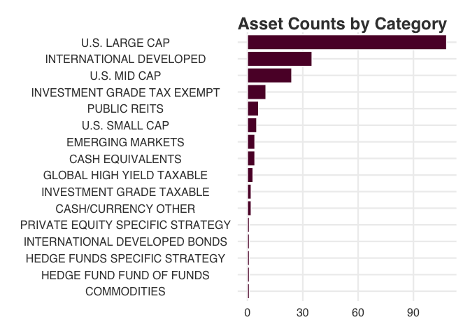

We see that the most diversity is in the Hartwig’s Large Cap stocks.

A more meaningful metric to asses the impact of these categories is the percentage of the portfolio made up by each category.

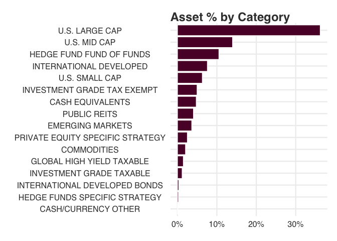

Again, Large Caps dominate the portfolio - providing over 30% of the total.

If each asset were invested in equally, this would mean each asset would make up 0.48% of the portfolio.

But of course each asset is not invested in equally.

A histogram of the percentage that each of these assets contribute to the overall portfolio can show the distribution of percentages. Here the x-axis shows ranges of percentage of the total portfolio and the y-axis gives the counts of the number of assets that fall into that range.

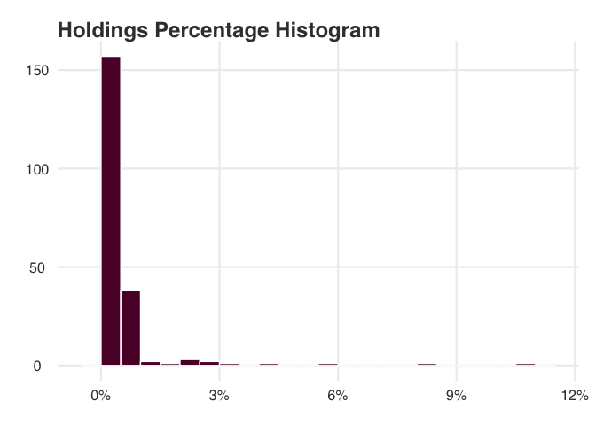

So, the vast majority of holdings are under 1% - as we would expect. The average among all holdings is indeed 0.48, However, there are also a handful of assets that fall well above that range.

Let’s take a look at these heavy hitters.

## Hartwig Top Holdings

Here are the assets in the Hartwig portfolio that make up more then 1% of the portfolio:

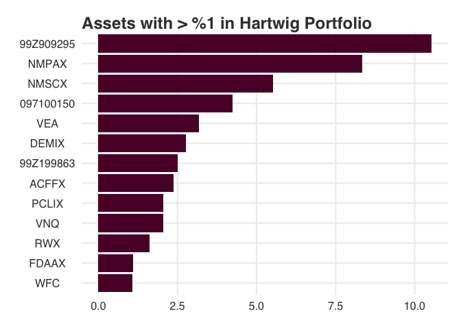

Together, these assets make up 47.34% of the portfolio. With a combined market value of $17,347,181.

So what are these assets?

The largest percentage of the portfolio is taken up by 99Z909295 at 10.52%. This is the fund-of-funds that makes up the Hedge fund portion of the portfolio.

NMPAX is the Columbia Mid-Cap Index Fund, while NMSCX is the Columbia Small-Cap Index Fund. Together, these two represent 13.87% of the portfolio.

097100150 is listed as the BOFA Tax-Exempt Reserves Trust Class. 99Z199863 is the Bain private equity fund.

The others fall into a range of categories. Here is a count by category for these top 13 assets.

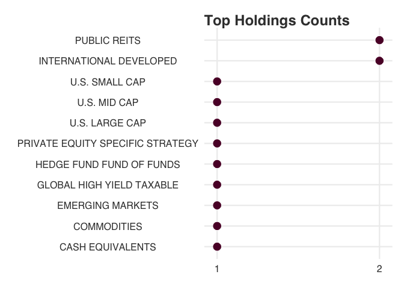

## Historical Returns of Top Assets

We acquire the historical prices of the 10 assets over the last year - using the external data source [Quandl](http://www.quandl.com/).

Here are the adjusted close prices for all the funds in this list.

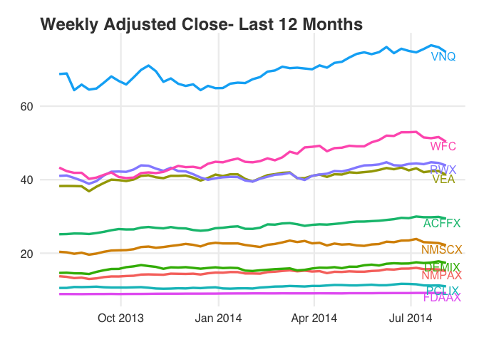

With this raw historical data, we can compute a number of metrics. Here is a table summarizing CAPM values for these assets when compared to the S&P 500 benchmark.

|  | NMPAX to SP_500 | NMSCX to SP_500 | VEA to SP_500 | DEMIX to SP_500 | ACFFX to SP_500 | PCLIX to SP_500 | VNQ to SP_500 | RWX to SP_500 | FDAAX to SP_500 | WFC to SP_500 |
| --- | --- | --- | --- | --- | --- | --- | --- | --- | --- | --- |
| Alpha | -0.0005 | -0.0008 | -0.0007 | 0.0016 | 0.0020 | 0.0006 | -0.0001 | -0.0001 | 0.0005 | 0.0005 |
| Beta | 1.0683 | 1.1037 | 0.9841 | 0.7860 | 0.4683 | 0.1108 | 0.7834 | 0.6312 | 0.0229 | 1.0704 |
| Beta+ | 1.2391 | 1.2055 | 0.9749 | 0.7796 | 0.7801 | 0.4542 | 1.1742 | 0.9599 | -0.0612 | 0.9792 |
| Beta- | 1.1964 | 0.7682 | 0.8399 | 1.1390 | 0.4333 | 0.1385 | 0.8978 | 0.8884 | 0.0531 | 0.9560 |
| R-squared | 0.8707 | 0.7250 | 0.6552 | 0.3474 | 0.3577 | 0.0154 | 0.3152 | 0.2896 | 0.0358 | 0.7135 |
| Annualized Alpha | -0.0264 | -0.0425 | -0.0366 | 0.0857 | 0.1069 | 0.0303 | -0.0041 | -0.0052 | 0.0275 | 0.0273 |
| Correlation | 0.9331 | 0.8515 | 0.8095 | 0.5894 | 0.5981 | 0.1240 | 0.5614 | 0.5381 | 0.1893 | 0.8447 |
| Correlation p-value | 0.0000 | 0.0000 | 0.0000 | 0.0000 | 0.0000 | 0.3810 | 0.0000 | 0.0000 | 0.1789 | 0.0000 |
| Tracking Error | 0.0400 | 0.0658 | 0.0684 | 0.1052 | 0.0788 | 0.1202 | 0.1125 | 0.1010 | 0.0943 | 0.0653 |
| Active Premium | -0.0220 | -0.0372 | -0.0456 | 0.0604 | 0.0433 | -0.0853 | -0.0389 | -0.0573 | -0.0957 | 0.0376 |
| Information Ratio | -0.5496 | -0.5654 | -0.6662 | 0.5747 | 0.5495 | -0.7094 | -0.3456 | -0.5675 | -1.0149 | 0.5756 |
| Treynor Ratio | 0.0974 | 0.0805 | 0.0818 | 0.2373 | 0.3616 | 0.3680 | 0.1113 | 0.1088 | 1.3283 | 0.1529 |

## Unrealized Gains and Losses

Turning back to the original holdings data, we can compare unrealized gains and losses.

Here we look at the holdings in the portfolio with losses. I assume this is over the entire time period since a particular asset was added to the portfolio. X axis is in negative dollars - so a larger number indicates more loss.

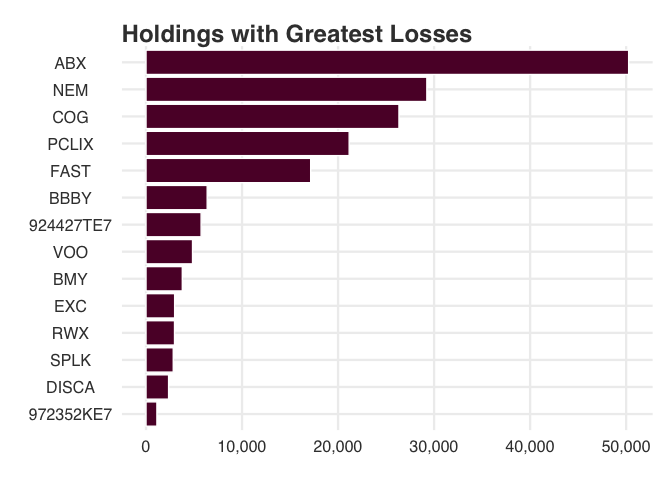

So, a single security, ABX, is responsible for a $50,000 unrealized loss. ABX is listed in the ‘International Developed’ section of the Hartwig Equities. ABX is [Barrick Gold Corporation](https://www.google.com/finance?cid=668912) and its price has been impacted by falling gold prices.